# hw4_random_forest

Polina Lipaeva

May 13, 2017

```r
library(randomForest)
library(rpart)
library(rattle)
library(rpart.plot)
library(RColorBrewer)
library(ggplot2)
```

## Восстановление возраста по данным метелирования

Данные для этой данной домашней работы мы возьмем из статьи “A novel strategy for forensic age prediction by DNA methylation and support vector regression model”, Cheng Xu et al, Scientific reports 2015. (Статья будет в архиве), где авторы попытались построить предсказатель возраста человека по данным метилирования отдельных CpG sites. Данные будут выглядеть следующим образом:

```r
#setwd('./IB/R_bionf/hw4/random_forest_hw/')
ages <- read.table("ages.tsv", sep="\t", header=1)
head(ages)
```

```
##   Sample Age              Array
## 1    F78  20 Sequenom Massarray
## 2    F79  21 Sequenom Massarray
## 3    F80  22 Sequenom Massarray
## 4    F81  23 Sequenom Massarray
## 5    F82  24 Sequenom Massarray
## 6    F83  25 Sequenom Massarray
```

```r
methylation <- read.table("methylation.tsv", sep="\t", header=1, row.names = 1, na.strings = "NA")
print(methylation[1:5, 1:5])
```

```
##    Primer Chr                   Position  F78  F79
## X1     P1   1                   43425337 0.24 0.09
## X2     P1   1 43425369;43425373;43425375 0.63 0.25
## X3     P1   1                   43425385 0.69 0.44
## X4     P1   1          43425452;43425460 0.88 0.45
## X5     P1   1                   43425479 0.89 0.43
```

```r
# транспонировать табличку, каждому возрасту должно соответсвовать уровень метилирования
transp_dt <- data.frame(t(methylation[,4:ncol(methylation)]))
transp_age <- cbind(transp_dt, Age=ages$Age)
transp_age[is.na(transp_age)] <- 0
```

## Предподготовка данных

```r
cor_data <- sapply(transp_age[-96], function(x) abs(cor(x, transp_age$Age)))
cor_data
```

```
##          X1          X2          X3          X4          X5          X6
## 0.290449842 0.118138394 0.198416546 0.024360100 0.149297840 0.038941076
##          X7          X8          X9         X10         X11         X12
## 0.104554115 0.161819527 0.125328673 0.198416546 0.140870614 0.071431986
##         X13         X14         X15         X16         X17         X18
## 0.248088904 0.052564252 0.174152133 0.161357043 0.172224631 0.195356346
##         X19         X20         X21         X22         X23         X24
## 0.273133938 0.145598963 0.584455620 0.025256394 0.452242717 0.076826399
##         X25         X26         X27         X28         X29         X30
## 0.591231332 0.533793673 0.495936200 0.580711887 0.001321062 0.017980612
##         X31         X32         X33         X34         X35         X36
## 0.001321062 0.017980612 0.001321062 0.110555013 0.028631364 0.021055240
##         X37         X38         X39         X40         X41         X42
## 0.194314695 0.052684542 0.154634249 0.162356020 0.035660419 0.120005591
##         X43         X44         X45         X46         X47         X48
## 0.152480775 0.003770213 0.038590432 0.134250795 0.156102331 0.156948386
##         X49         X50         X51         X52         X53         X54
## 0.055624520 0.073710913 0.240080572 0.162356020 0.255869949 0.151623946
##         X55         X56         X57         X58         X59         X60
## 0.200597009 0.179362499 0.118327071 0.306294583 0.220431975 0.466115877
##         X61         X62         X63         X64         X65         X66
## 0.571123120 0.402077933 0.140191468 0.524494259 0.077053789 0.031814348
##         X67         X68         X69         X70         X71         X72
## 0.192737440 0.540669616 0.142231244 0.570831678 0.041280973 0.061705180
##         X73         X74         X75         X76         X77         X78
## 0.075816509 0.046947059 0.038834285 0.571403656 0.597807785 0.182170503
##         X79         X80         X81         X82         X83         X84
## 0.198002240 0.088237706 0.129791483 0.036972608 0.031542915 0.220124629
##         X85         X86         X87         X88         X89         X90
## 0.178419266 0.208331640 0.255376003 0.157357813 0.342260421 0.409979203
##         X91         X92         X93         X94         X95
## 0.195721653 0.431102964 0.441276557 0.162481257 0.253685646
```

```r
top10 <- head(sort(cor_data, decreasing = T), 10)
top10_dt <- cbind(Age=ages$Age, transp_age[names(top10)])
top10_dt
```

```
##      Age  X77  X25  X21  X28  X76  X61  X70  X68  X26  X64
## F78   20 0.68 0.13 0.02 0.61 0.82 0.39 0.93 0.78 0.10 0.18
## F79   21 0.67 0.68 0.20 0.88 0.76 0.41 0.88 0.66 0.53 0.18
## F80   22 0.65 0.47 0.12 0.00 0.76 0.39 0.86 0.44 0.37 0.17
## F81   23 0.61 0.45 0.13 0.74 0.74 0.38 0.81 0.65 0.38 0.14
## F82   24 0.64 0.16 0.03 0.68 0.81 0.41 0.89 0.64 0.11 0.13
## F83   25 0.67 0.64 0.18 0.80 0.77 0.35 0.82 0.74 0.63 0.12
## F87   26 0.67 0.18 0.08 0.46 0.73 0.33 0.66 0.61 0.42 0.11
## F89   27 0.64 0.20 0.05 0.51 0.78 0.29 0.46 0.45 0.34 0.10
## F84   28 0.73 0.21 0.10 0.39 0.94 0.47 0.46 0.46 0.29 0.20
## F85   29 0.56 0.79 0.27 0.80 0.74 0.38 0.95 0.63 0.70 0.09
## F86   30 0.64 0.20 0.06 0.29 0.75 0.37 0.81 0.44 0.32 0.11
## F88   31 0.63 0.47 0.16 0.41 0.74 0.34 0.84 0.68 0.47 0.13
## F90   32 0.58 0.21 0.09 0.45 0.76 0.35 0.56 0.53 0.37 0.13
## F91   32 0.66 0.00 0.00 0.00 0.77 0.00 0.00 0.00 0.00 0.00
## F92   33 0.63 0.21 0.04 0.00 0.78 0.43 0.73 0.69 0.50 0.16
## F13   34 0.67 0.18 0.08 0.45 0.78 0.40 0.70 0.53 0.25 0.13
## F14   35 0.48 0.11 0.00 0.46 0.63 0.34 0.68 0.56 0.17 0.11
## F15   38 0.53 0.30 0.14 0.54 0.71 0.27 0.67 0.39 0.54 0.10
## F17   39 0.48 0.48 0.18 0.50 0.60 0.13 0.50 0.39 0.55 0.05
## F18   40 0.63 0.11 0.00 0.62 0.76 0.22 0.58 0.52 0.31 0.11
## F20   41 0.49 0.37 0.12 0.46 0.59 0.18 0.56 0.56 0.37 0.07
## F21   42 0.62 0.15 0.05 0.51 0.71 0.31 0.20 0.20 0.41 0.08
## F22   43 0.60 0.15 0.02 0.32 0.76 0.00 0.00 0.00 0.29 0.00
## F23   44 0.55 0.17 0.08 0.41 0.69 0.20 0.25 0.29 0.02 0.11
## F24   46 0.49 0.08 0.00 0.33 0.65 0.30 0.25 0.29 0.06 0.10
## F25   47 0.62 0.21 0.15 0.44 0.74 0.37 0.59 0.36 0.56 0.11
## F27   50 0.58 0.20 0.08 0.51 0.74 0.00 0.41 0.39 0.25 0.00
## F28   51 0.60 0.02 0.00 0.06 0.72 0.37 0.31 0.28 0.00 0.12
## F29   52 0.52 0.26 0.11 0.42 0.64 0.26 0.27 0.30 0.15 0.06
## F30   53 0.40 0.21 0.02 0.46 0.65 0.00 0.29 0.30 0.27 0.04
## F31   54 0.63 0.20 0.06 0.50 0.79 0.00 0.50 0.49 0.30 0.08
## F33   55 0.42 0.11 0.01 0.40 0.58 0.28 0.57 0.55 0.11 0.06
## F34   56 0.60 0.19 0.08 0.44 0.71 0.28 0.08 0.14 0.25 0.14
## F93   57 0.54 0.05 0.00 0.00 0.65 0.00 0.50 0.33 0.00 0.00
## F94   58 0.62 0.07 0.00 0.00 0.77 0.30 0.56 0.57 0.00 0.09
## F95   59 0.59 0.13 0.00 0.00 0.70 0.42 0.71 0.64 0.00 0.15
## F96   60 0.57 0.06 0.00 0.00 0.71 0.00 0.29 0.30 0.00 0.00
## F97   61 0.68 0.07 0.00 0.00 0.80 0.46 0.08 0.06 0.19 0.12
## F98   62 0.52 0.05 0.00 0.00 0.71 0.00 0.59 0.51 0.00 0.00
## F99   63 0.47 0.07 0.00 0.00 0.62 0.00 0.40 0.27 0.00 0.06
## F100  64 0.60 0.14 0.00 0.00 0.70 0.31 0.53 0.53 0.00 0.09
## F101  65 0.51 0.14 0.05 0.44 0.59 0.00 0.37 0.24 0.46 0.00
## F102  66 0.52 0.17 0.05 0.40 0.70 0.46 0.50 0.45 0.41 0.17
## F103  67 0.57 0.15 0.00 0.29 0.72 0.00 0.39 0.37 0.00 0.06
## F104  68 0.53 0.07 0.00 0.42 0.66 0.00 0.18 0.15 0.16 0.11
## F105  69 0.46 0.09 0.00 0.00 0.62 0.32 0.40 0.32 0.42 0.13
## F106  71 0.54 0.06 0.00 0.00 0.70 0.00 0.35 0.35 0.00 0.00
## F107  72 0.54 0.04 0.00 0.00 0.66 0.00 0.28 0.15 0.00 0.00
## F49   75 0.50 0.05 0.00 0.31 0.64 0.00 0.35 0.29 0.00 0.06
## F113  80 0.38 0.03 0.00 0.00 0.54 0.00 0.39 0.14 0.00 0.00
```

## Предподготовка данных (machine learning)

```r
set.seed(77)
training <- sample(1:50, 40)
validation <- (1:50)[-training]

train <- top10_dt[training, ]
valid <- top10_dt[validation, ]
```

## Функция-обертка

```r
wrapper <- function(train.data, train.response,
                    test.data, test.response,
                    runs.number=50, ...) {

  forest <- lapply(1:runs.number, function(x) randomForest(train.response ~ ., data=train.data[-1], ...))
  train_rmse <- lapply(forest, function(x) sqrt((1/(nrow(train.data[-1]))) * sum((predict(x, train.data[-1]) - train.response) ** 2)))
  valid_rmse <- lapply(forest, function(x) sqrt((1/(nrow(test.data[-1]))) * sum((predict(x, test.data[-1]) - test.response) ** 2)))
  tr_rmse_vect <- rapply(train_rmse, c)
  val_rmse_vect <- rapply(valid_rmse, c)
  tr_mean_rmse <- mean(tr_rmse_vect)
  val_mean_rmse <- mean(val_rmse_vect)
  return(c(tr_mean_rmse, val_mean_rmse))
}
# запуск randomForest с аргументами по умолчанию 50 раз и подсчет средней ошибки
errors.defaults <- wrapper(train, train$Age, valid, valid$Age, 50)
print(errors.defaults)
```

```
## [1] 5.047715 9.644624
```

```r
# запуск randomForest всего с 1 деревом внутри 50 раз и подсчет средней ошики
errors.ntree1 <- wrapper(train, train$Age, valid, valid$Age, 50, ntree=1)
print(errors.ntree1)
```

```
## [1]  9.661646 13.275275
```

Неудивительно, однако случайный лес состоящий из одного дерева предсказывает оба датасета хуже, чем лес, построенный по умолчанию (в нём 500 деревьев).

```r
# запуск randomForest со всеми вершинами (nodesize=1), replace=F, sampsize=N, mtry=M - переобучение
errors.overfit <- wrapper(train, train$Age, valid, valid$Age, 50,
                          nodesize=1, replace=F, sampsize=40, mtry=10, ntree=100)
print(errors.overfit)
```

```
## [1]  0.00000 13.56213
```

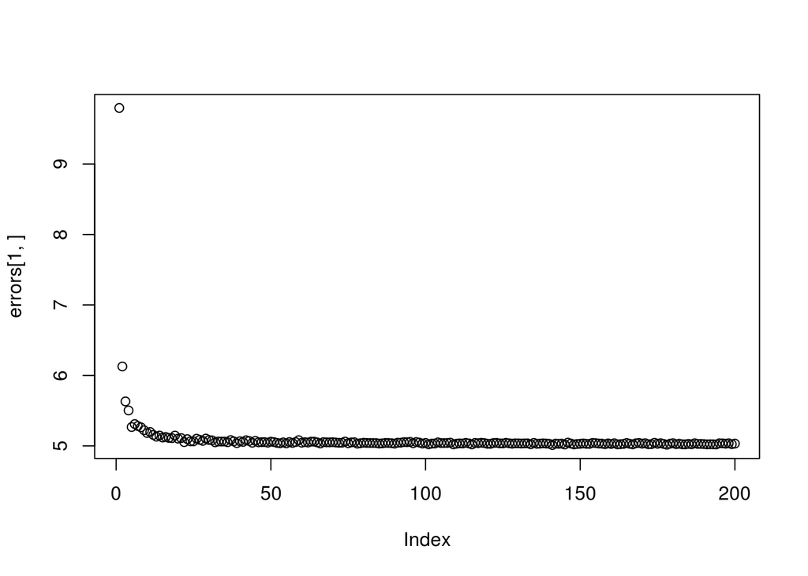

```r
ntrees <- seq(1, 1000, 5)
errors <- sapply(ntrees, function(x) wrapper(train, train$Age, valid, valid$Age, ntree=x))
plot(errors[1,])
```

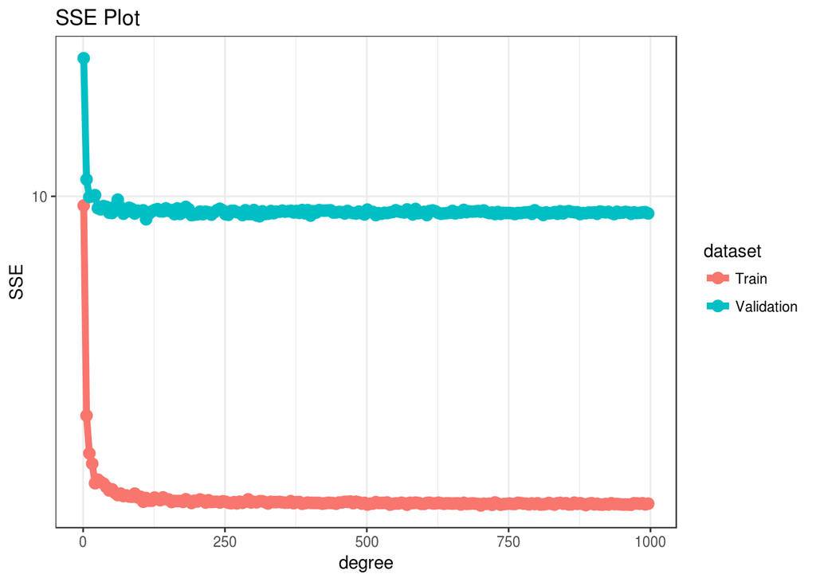

```r
toPlot <- rbind(
data.frame(degree=ntrees, SSE=errors[1,], dataset="Train"),
data.frame(degree=ntrees, SSE=errors[2,], dataset="Validation")
  )
ggplot(data=toPlot, aes(x=degree, y=SSE, color=dataset)) +
    geom_point(size=3) + scale_y_log10() +
    geom_line(size=2) + ggtitle("SSE Plot") +
    theme_bw()
```

REPLACE and SAMPSIZE

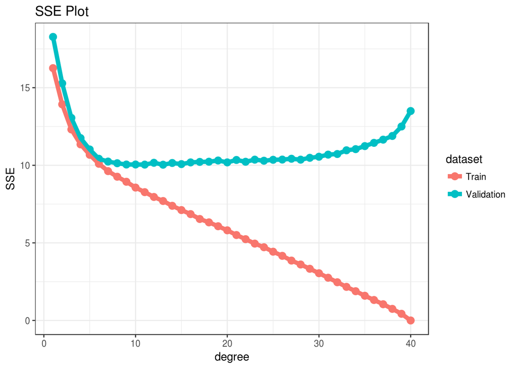

```r
samplesize <- 1:40
samplesize_ch <- sapply(samplesize, function(x) wrapper(train, train$Age, valid, valid$Age, 50,
                          nodesize=1, replace=F, sampsize=x, mtry=10, ntree=250))
toPlot2 <- rbind(
data.frame(degree=samplesize, SSE=samplesize_ch[1,], dataset="Train"),
data.frame(degree=samplesize, SSE=samplesize_ch[2,], dataset="Validation")
  )
# график зависимости ошибки от sampsize (1:40) при replace=F
ggplot(data=toPlot2, aes(x=degree, y=SSE, color=dataset)) +
    geom_point(size=3) +
    geom_line(size=2) + ggtitle("SSE Plot") +
    theme_bw()
```